# tenaciousD data analysis

Ross Cunning

May 17, 2016

## Load libraries and prepare data for analysis

The “setup.R” script loads required libraries and imports data. Total S/H ratios and proportion clade D are calculated for each sample, and corals are categorized as C-dominated or D-dominated based on their dominant symbiont at time zero. Relative changes in Fv/Fm are calculated for each sample. After sourcing this script, the data are ready to be analyzed.

### Experimental design

Number of C-dominated and D-dominated coral cores in each treatment

```r
n <- with(subset(data, time==0), table(dom, ramp))
n <- addmargins(n)
pander(n, style="grid")
```

|  | cool | heat | Sum |
| --- | --- | --- | --- |
| **C** | 19 | 21 | 40 |
| **D** | 53 | 66 | 119 |
| **Sum** | 72 | 87 | 159 |

Relative proportions of background symbionts in each group

```r
# Mean and median amount of C in the C-dominated corals
with(subset(data, time==0 & dom=="C"), 1-mean(propD, na.rm=T)); with(subset(data, time==0 & dom=="C"), 1-median(propD, na.rm=T))
```

```
## [1] 0.9635831
```

```
## [1] 1
```

```r
# Mean and median amount of D in the D-dominated corals
with(subset(data, time==0 & dom=="D"), mean(propD, na.rm=T)); with(subset(data, time==0 & dom=="D"), median(propD, na.rm=T))
```

```
## [1] 0.9791153
```

```
## [1] 0.9989026
```

## Analyze Fv/Fm data

We utilize generalized additive mixed models (GAMMs) to model relative Fv/Fm values as a smooth function of time, with dominant symbiont clade as a fixed effect and mother colony and core as random effects. We fit separate models for the cooling treatment and the heating treatment. After fitting the models, we simulate (n=1000) from the posterior distribution of the parameters of the fitted models and generate 84% confidence intervals on fitted values for visual display purposes (non-overlapping 84% confidence intervals in Fig. 1 are approximately equal to a significant difference at p < 0.05). To formally conduct this test as well to determine whether Fv/Fm differs between C-dominated and D-dominated corals on each date, we also generate a 95% confidence interval on the difference between these groups from the simulated values, and test whether it includes zero.

### Cooling treatment

#### Plot raw data

Here, Fv/Fm data (mean ± s.d.) are plotted for clade C- and D-dominated corals.

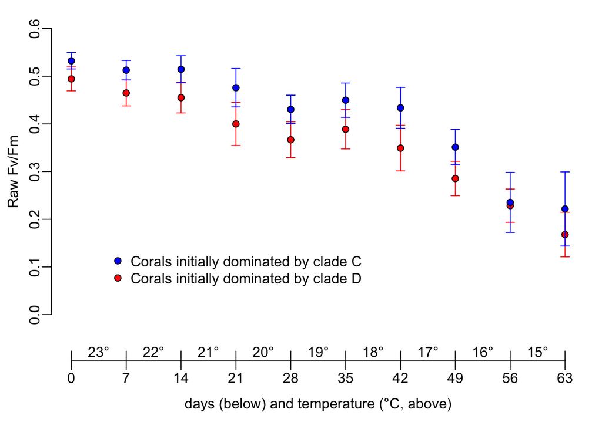

#### Fit GAMM on relative change in Fv/Fm data

```r
# Fit GAMM for cooling treatment
gm.cool <- gamm(rfvfm ~ dom + s(time, by=dom, k=4), random=list(mother=~1, sample=~1),
                data=subset(data, ramp=="cool"), na.action=na.omit)
summary(gm.cool$gam)
```

```
##
## Family: gaussian
## Link function: identity
##
## Formula:
## rfvfm ~ dom + s(time, by = dom, k = 4)
##
## Parametric coefficients:
##             Estimate Std. Error t value Pr(>|t|)
## (Intercept)  0.78162    0.01078  72.477  < 2e-16 ***
## domD        -0.05320    0.01257  -4.232 2.63e-05 ***
## ---
## Signif. codes:  0 '***' 0.001 '**' 0.01 '*' 0.05 '.' 0.1 ' ' 1
##
## Approximate significance of smooth terms:
##                edf Ref.df    F p-value
## s(time):domC 2.944  2.944  610  <2e-16 ***
## s(time):domD 2.978  2.978 1765  <2e-16 ***
## ---
## Signif. codes:  0 '***' 0.001 '**' 0.01 '*' 0.05 '.' 0.1 ' ' 1
##
## R-sq.(adj) =  0.872
##   Scale est. = 0.0040493  n = 718
```

```r
# Get fitted values
pdat.cool <- expand.grid(time=seq(0,63,1), ramp=factor("cool"), dom=factor(c("C", "D")))
gm.cool.pred <- data.frame(cbind(pdat.cool, fit=predict(gm.cool$gam, pdat.cool)))
# Simulate from multivariate normal distribution of fitted model
set.seed(789)
Rbeta <- mvrnorm(n = 1000, coef(gm.cool$gam), vcov(gm.cool$gam))
Xp <- predict(gm.cool$gam, newdata = pdat.cool, type = "lpmatrix")
sim <- Xp %*% t(Rbeta)
# Extract 84% confidence intervals from simulation
gm.cool.pred$lci <- apply(sim, 1, quantile, 0.08)
gm.cool.pred$uci <- apply(sim, 1, quantile, 0.92)
```

#### Plot relative change data with fitted model

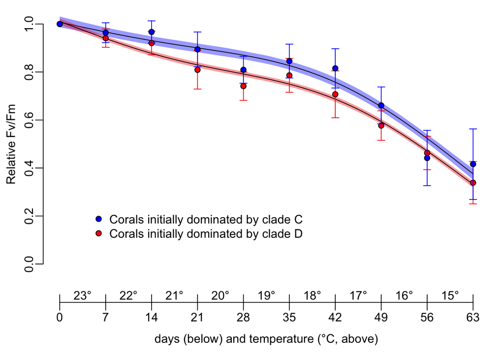

#### Test if Fv/Fm is the same in C- and D-dominated corals at each sampling date

```r
# Calculate 95% confidence interval on difference between C and D corals at each sampling dates from simulation
sim1 <- cbind(pdat.cool, sim)
sim1 <- sim1[sim1$time %in% c(0,7,14,21,28,35,42,49,56,63), ]
sim1split <- split(sim1, f=sim1$time, drop=T)
CDdiff.95CI <- lapply(sim1split, function(x) quantile(apply(x[,4:ncol(x)], 2, diff), c(0.025, 0.975)))
# Test if 95% CI on difference between C and D corals contains zero
cool.test0 <- lapply(CDdiff.95CI, FUN=function(x) (x[1] < 0 & 0 < x[2])[[1]])
t(matrix(cool.test0, dimnames=list(day=names(cool.test0), Ho="C-dom = D-dom")))
```

```
##                day
## Ho              0    7    14    21    28    35    42    49    56    63
##   C-dom = D-dom TRUE TRUE FALSE FALSE FALSE FALSE FALSE FALSE FALSE FALSE
```

### Heating treatment

#### Plot raw data

Here, Fv/Fm data (mean ± s.d.) are plotted for clade C- and D-dominated corals.

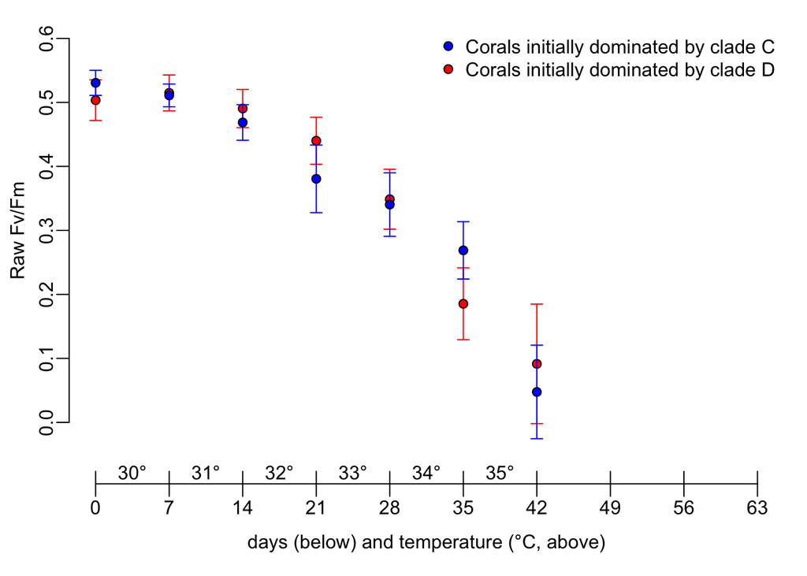

```r
# Fit GAMM for heating treatment
gm.heat <- gamm(rfvfm ~ dom + s(time, by=dom, k=4), random=list(mother=~1, sample=~1),
                data=subset(data, ramp=="heat"), na.action=na.omit)
summary(gm.heat$gam)
```

```
##
## Family: gaussian
## Link function: identity
##
## Formula:
## rfvfm ~ dom + s(time, by = dom, k = 4)
##
## Parametric coefficients:
##             Estimate Std. Error t value Pr(>|t|)
## (Intercept) 0.699803   0.008239  84.943  < 2e-16 ***
## domD        0.046555   0.009317   4.997 7.81e-07 ***
## ---
## Signif. codes:  0 '***' 0.001 '**' 0.01 '*' 0.05 '.' 0.1 ' ' 1
##
## Approximate significance of smooth terms:
##                edf Ref.df      F p-value
## s(time):domC 2.918  2.918  450.4  <2e-16 ***
## s(time):domD 2.976  2.976 1586.5  <2e-16 ***
## ---
## Signif. codes:  0 '***' 0.001 '**' 0.01 '*' 0.05 '.' 0.1 ' ' 1
##
## R-sq.(adj) =  0.915
##   Scale est. = 0.0083549  n = 567
```

```r
# Get fitted values
pdat.heat <- expand.grid(time=seq(0,42,1), ramp=factor("heat"), dom=factor(c("C", "D")))
gm.heat.pred <- data.frame(cbind(pdat.heat, fit=predict(gm.heat$gam, pdat.heat)))
# Simulate from multivariate normal distribution of fitted model
set.seed(789)
Rbeta <- mvrnorm(n = 1000, coef(gm.heat$gam), vcov(gm.heat$gam))
Xp <- predict(gm.heat$gam, newdata = pdat.heat, type = "lpmatrix")
sim <- Xp %*% t(Rbeta)
# Extract 95% confidence intervals of simulated values for plotting
gm.heat.pred$lci <- apply(sim, 1, quantile, 0.08)
gm.heat.pred$uci <- apply(sim, 1, quantile, 0.92)
```

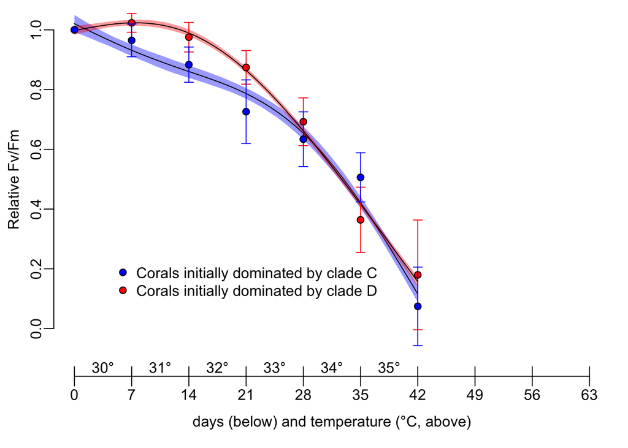

#### Test if Fv/Fm is the same in C- and D-dominated corals at each sampling date

```r
# Calculate 95% confidence interval on difference between C and D corals at select dates (=sampling dates)
sim1 <- cbind(pdat.heat, sim)
sim1 <- sim1[sim1$time %in% c(0,7,14,21,28,35,42), ]
sim1split <- split(sim1, f=sim1$time, drop=T)
CDdiff.95CI <- lapply(sim1split, function(x) quantile(apply(x[,4:ncol(x)], 2, diff), c(0.025, 0.975)))
# Test if 95% CI on difference between C and D corals contains zero
heat.test0 <- lapply(CDdiff.95CI, FUN=function(x) (x[1] < 0 & 0 < x[2])[[1]])
t(matrix(heat.test0, dimnames=list(day=names(heat.test0), Ho="C-dom = D-dom")))
```

```
##                day
## Ho              0    7     14    21    28   35   42
##   C-dom = D-dom TRUE FALSE FALSE FALSE TRUE TRUE TRUE
```

Relative Fv/Fm is significantly higher (p < 0.05) in D-dominated corals than C-dominated corals at day 7, 14, and 21.

## Analyze symbiont abundance (S/H ratios)

Symbiont abundance is analyzed for each treatment using a linear mixed model with log-transformed total symbiont to host cell ratio (S/H ratio) as the response variable, with a fixed effect of time and dominant symbiont clade, and random effects of mother colony and core. After fitting the model, Dunnett’s tests are performed within each group of corals to determine if the total S/H ratio is different from time zero. When significant differences were identified (p<0.05), the percent change in S/H ratio was calculated relative to time zero.

### Cooling treatment

```r
# Fit linear mixed model
coolSHmod <- lmerTest::lmer(log10(tot.SH) ~ timef * dom + (1|mother/sample), data=subset(data, ramp=="cool"), na.action=na.omit)
summary(coolSHmod)
```

```
## Linear mixed model fit by REML t-tests use Satterthwaite approximations
##   to degrees of freedom [lmerMod]
## Formula: log10(tot.SH) ~ timef * dom + (1 | mother/sample)
##    Data: subset(data, ramp == "cool")
##
## REML criterion at convergence: 422.4
##
## Scaled residuals:
##      Min       1Q   Median       3Q      Max
## -2.30177 -0.66595 -0.03113  0.58201  2.51480
##
## Random effects:
##  Groups        Name        Variance Std.Dev.
##  sample:mother (Intercept) 0.02869  0.1694
##  mother        (Intercept) 0.04536  0.2130
##  Residual                  0.28416  0.5331
## Number of obs: 239, groups:  sample:mother, 71; mother, 9
##
## Fixed effects:
##               Estimate Std. Error        df t value Pr(>|t|)
## (Intercept)   -0.94824    0.14694  71.67000  -6.453 1.13e-08 ***
## timef28       -0.24163    0.17843 165.48000  -1.354    0.178
## timef42        0.02036    0.17848 165.85000   0.114    0.909
## timef63       -1.22035    0.18511 170.55000  -6.592 5.19e-10 ***
## domD           0.68286    0.15554 216.29000   4.390 1.77e-05 ***
## timef28:domD   0.12496    0.21050 167.14000   0.594    0.554
## timef42:domD  -0.19780    0.21147 168.29000  -0.935    0.351
## timef63:domD   1.03698    0.22561 175.62000   4.596 8.19e-06 ***
## ---
## Signif. codes:  0 '***' 0.001 '**' 0.01 '*' 0.05 '.' 0.1 ' ' 1
##
## Correlation of Fixed Effects:
##             (Intr) timf28 timf42 timf63 domD   tm28:D tm42:D
## timef28     -0.571
## timef42     -0.570  0.469
## timef63     -0.551  0.452  0.454
## domD        -0.727  0.539  0.538  0.520
## timef28:dmD  0.485 -0.848 -0.397 -0.383 -0.669
## timef42:dmD  0.482 -0.396 -0.844 -0.384 -0.665  0.490
## timef63:dmD  0.452 -0.371 -0.372 -0.820 -0.624  0.459  0.458
```

```r
# Conduct Dunnett's post-hoc tests
cool.dunnett <- rbind(contrast(lsmeans::lsmeans(coolSHmod, specs=c("timef", "dom")), "dunnett", by="dom"))
# Calculate percent change relative to time zero and extract significant contrasts
cool.dunnett <- within(data.frame(summary(cool.dunnett)), {
  loss <- paste0(sprintf("%.1f", round(-(1-(10^estimate)) * 100, 1)), "%")
  day <- substr(contrast, 1, 2)
})
cool.diff <- cool.dunnett[cool.dunnett$p.value < 0.05, ]
cool.diff
```

```
##   dom contrast  estimate        SE      df   t.ratio      p.value day
## 3   C   63 - 0 -1.220348 0.1853262 172.479 -6.584861 2.633912e-09  63
##     loss
## 3 -94.0%
```

#### Plot raw data and annotate significant changes in S/H ratio

Mean total S/H ratios ± s.d. are plotted for C-dominated and D-dominated corals. Significant differences within each group relative to time zero are indicated with asterisks and the percent change in S/H ratio.

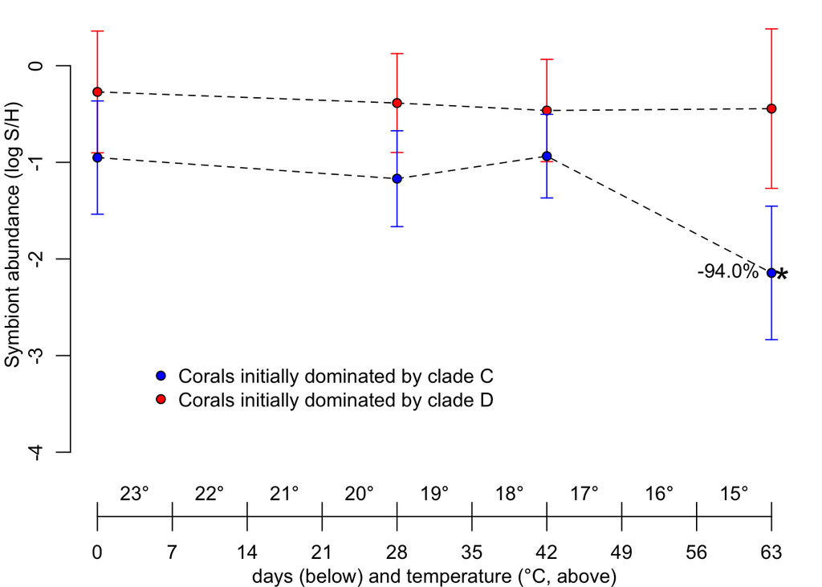

### Heating treatment

```r
# Fit linear mixed model
heatSHmod <- lmerTest::lmer(log10(tot.SH) ~ timef * dom + (1|mother/sample), data=subset(data, ramp=="heat"), na.action=na.omit)
summary(heatSHmod)
```

```
## Linear mixed model fit by REML t-tests use Satterthwaite approximations
##   to degrees of freedom [lmerMod]
## Formula: log10(tot.SH) ~ timef * dom + (1 | mother/sample)
##    Data: subset(data, ramp == "heat")
##
## REML criterion at convergence: 465.6
##
## Scaled residuals:
##     Min      1Q  Median      3Q     Max
## -1.9562 -0.6315 -0.0860  0.4574  3.5960
##
## Random effects:
##  Groups        Name        Variance Std.Dev.
##  sample:mother (Intercept) 0.04442  0.2108
##  mother        (Intercept) 0.05729  0.2393
##  Residual                  0.36265  0.6022
## Number of obs: 231, groups:  sample:mother, 87; mother, 9
##
## Fixed effects:
##              Estimate Std. Error       df t value Pr(>|t|)
## (Intercept)   -0.9555     0.1691  63.5500  -5.650 4.04e-07 ***
## timef28       -1.9337     0.1997 150.4000  -9.685  < 2e-16 ***
## timef42       -2.5264     0.2039 159.4700 -12.393  < 2e-16 ***
## domD           0.6676     0.1710 214.2900   3.905 0.000126 ***
## timef28:domD   1.7614     0.2277 150.1000   7.736 1.39e-12 ***
## timef42:domD   1.2016     0.2334 157.4400   5.148 7.76e-07 ***
## ---
## Signif. codes:  0 '***' 0.001 '**' 0.01 '*' 0.05 '.' 0.1 ' ' 1
##
## Correlation of Fixed Effects:
##             (Intr) timf28 timf42 domD   tm28:D
## timef28     -0.532
## timef42     -0.532  0.446
## domD        -0.769  0.525  0.525
## timef28:dmD  0.466 -0.877 -0.391 -0.619
## timef42:dmD  0.471 -0.390 -0.873 -0.620  0.458
```

```r
# Conduct Dunnett's post-hoc tests
heat.dunnett <- rbind(contrast(lsmeans::lsmeans(heatSHmod, specs=c("timef", "dom")), "dunnett", by="dom"))
# Calculate percent change relative to time zero and extract significant contrasts
heat.dunnett <- within(data.frame(summary(heat.dunnett)), {
  loss <- paste0(sprintf("%.1f", round(-(1-(10^estimate)) * 100, 1)), "%")
  day <- substr(contrast, 1, 2)
})
heat.diff <- heat.dunnett[heat.dunnett$p.value < 0.05, ]
heat.diff
```

```
##   dom contrast  estimate        SE       df    t.ratio      p.value day
## 1   C   28 - 0 -1.933705 0.1998431 150.3266  -9.676116 2.220446e-16  28
## 2   C   42 - 0 -2.526420 0.2041643 159.4178 -12.374445 0.000000e+00  42
## 4   D   42 - 0 -1.324835 0.1140035 150.5943 -11.621007 0.000000e+00  42
##     loss
## 1 -98.8%
## 2 -99.7%
## 4 -95.3%
```

#### Plot raw data and annotate significant changes in S/H ratio

Mean total S/H ratios ± s.d. are plotted for C-dominated and D-dominated corals. Significant differences within each group relative to time zero are indicated with asterisks and the percent change in S/H ratio.

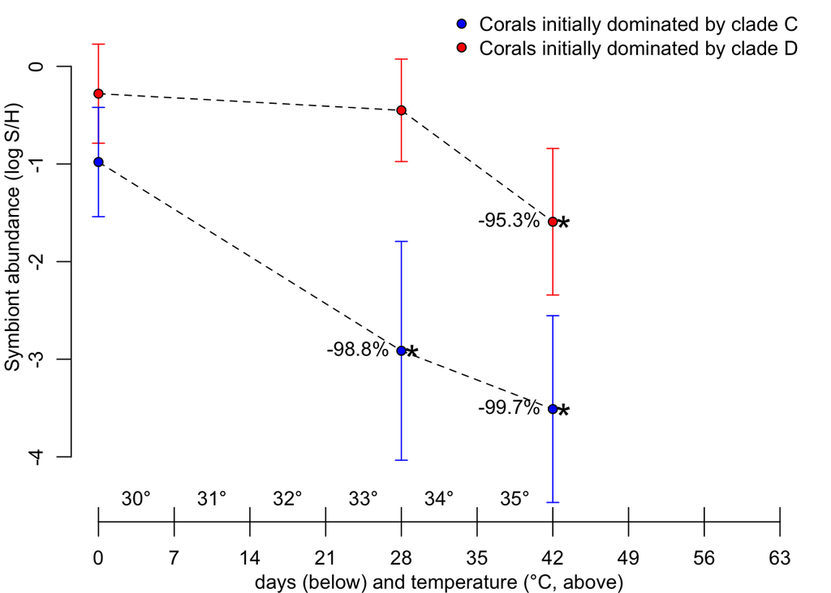

## Analyze dynamics of dominant and non-dominant symbionts together

The previous analysis was on the total symbiont to host cell ratio, but did not distinguish between clade C and D symbionts. Clade D symbionts are present at lower levels in clade C-dominated corals, and vice versa. Here, we analyze the dynamics of both clades simultaneously within C- and D-dominated corals using a linear mixed model approach. To analyze the dynamics of both (dominant and non-dominant) clades within corals in each treatment, log-transformed clade-specific S/H ratios were modeled as a function of clade identity, time, and dominant clade identity, with mother colony and core as random effects. Significant changes in either clade C or D abundance within C- and D-dominated corals across consecutive sampling intervals were evaluated with the package lsmeans.

### Cooling treatment

```r
# Rearrange data in order to use clade identity as fixed effect in linear model
df <- data[!is.na(data$tot.SH), ]
df2 <- melt(df, id.vars=c(1:6,9:14), value.name="SH")
colnames(df2)[colnames(df2)=="variable"] <- "clade"
# Fit linear mixed model for cooling treatment
coolmod <- lmerTest::lmer(log10(SH) ~ timef * dom * clade + (timef+dom+clade|mother/sample), data=subset(df2, ramp=="cool"))
print(summary(coolmod), correlation=FALSE)
```

```
## Linear mixed model fit by REML ['lmerMod']
## Formula:
## log10(SH) ~ timef * dom * clade + (timef + dom + clade | mother/sample)
##    Data: subset(df2, ramp == "cool")
##
## REML criterion at convergence: 977.3
##
## Scaled residuals:
##     Min      1Q  Median      3Q     Max
## -3.7827 -0.4272  0.0116  0.4545  2.0418
##
## Random effects:
##  Groups        Name        Variance Std.Dev. Corr
##  sample:mother (Intercept) 0.140712 0.37512
##                timef28     0.211788 0.46020  -0.98
##                timef42     0.381438 0.61761  -0.84  0.78
##                timef63     0.496438 0.70458  -0.43  0.45  0.72
##                domD        1.032806 1.01627   0.21 -0.20 -0.36 -0.39
##                cladeD.SH   1.174346 1.08367  -0.28  0.29  0.38  0.29 -0.96
##  mother        (Intercept) 0.117483 0.34276
##                timef28     0.026826 0.16379  -0.72
##                timef42     0.024156 0.15542  -0.94  0.91
##                timef63     0.112207 0.33497  -0.08  0.75  0.41
##                domD        0.005899 0.07681  -0.35  0.89  0.64  0.95
##                cladeD.SH   0.078406 0.28001  -0.08 -0.63 -0.25 -0.99 -0.90
##  Residual                  0.168441 0.41042
## Number of obs: 478, groups:  sample:mother, 71; mother, 9
##
## Fixed effects:
##                        Estimate Std. Error t value
## (Intercept)            -0.96649    0.17172  -5.628
## timef28                -0.22993    0.18190  -1.264
## timef42                 0.02208    0.20536   0.108
## timef63                -1.35258    0.25235  -5.360
## domD                   -1.85877    0.21957  -8.466
## cladeD.SH              -2.41145    0.29738  -8.109
## timef28:domD            0.48906    0.20719   2.360
## timef42:domD            0.36304    0.23658   1.535
## timef63:domD            1.03439    0.27612   3.746
## timef28:cladeD.SH       0.07354    0.19505   0.377
## timef42:cladeD.SH      -0.02825    0.19517  -0.145
## timef63:cladeD.SH       1.24191    0.20300   6.118
## domD:cladeD.SH          4.96035    0.33332  14.882
## timef28:domD:cladeD.SH -0.49605    0.23081  -2.149
## timef42:domD:cladeD.SH -0.59754    0.23225  -2.573
## timef63:domD:cladeD.SH -1.12579    0.24950  -4.512
## convergence code: 1
## unable to evaluate scaled gradient
## Model failed to converge: degenerate  Hessian with 1 negative eigenvalues
## maxfun < 10 * length(par)^2 is not recommended.
```

```r
# Test for differences across consecutive time points in both clades' S/H ratios
coolmod.lsm <- lsmeans(coolmod, specs=c("clade", "timef", "dom"))
coolmod.contr <- data.frame(summary(contrast(coolmod.lsm, "consec", by=c("dom", "clade"))))
coolmod.lsm <- data.frame(summary(coolmod.lsm))
# Identify significant differences and calculate percent change
coolmod.sigs <- coolmod.contr[coolmod.contr$p.value < 0.05, ]
coolmod.sigs$loss <- -(1-10^coolmod.sigs$estimate)
coolmod.sigs <- cbind(colsplit(coolmod.sigs$contrast, pattern="-", names=c("timef", "start")), coolmod.sigs)
coolmod.sigs
```

```
##   timef start contrast dom clade   estimate        SE       df   t.ratio
## 3    63    42  63 - 42   C  C.SH -1.3746574 0.2305343 41.02071 -5.962918
## 9    63    42  63 - 42   D  C.SH -0.7033055 0.1767138 17.07262 -3.979914
##        p.value       loss
## 3 2.221657e-06 -0.9577971
## 9 2.717789e-03 -0.8019867
```

#### Plot clades C and D dynamics in cooling treatment

Fitted values for clade C and D S/H ratio (±SE) are plotted for C-dominated and D-dominated corals at each time point. Consecutive time points are connected by arrows, and significant differences between time points are indicated by the letter of the clade that was significantly different.

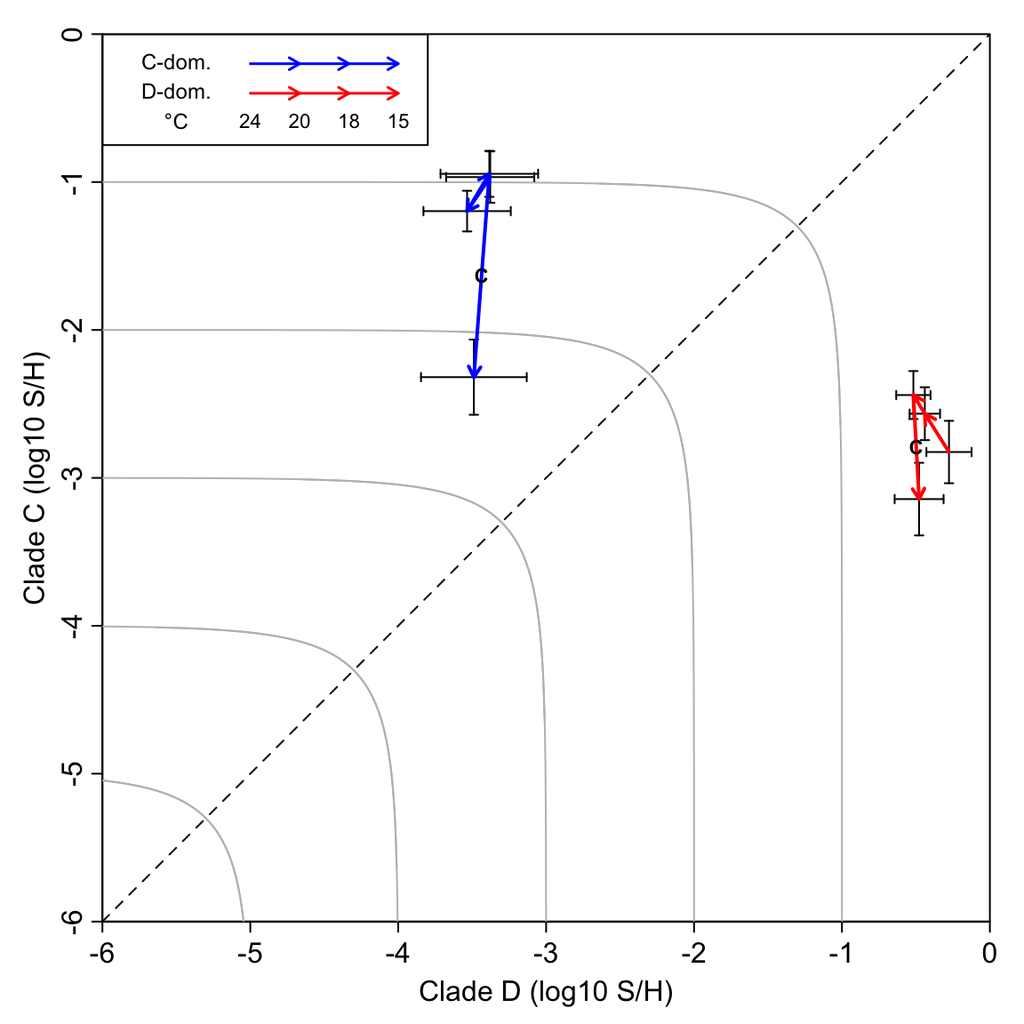

### Heating treatment

```r
# Rearrange data in order to use clade identity as fixed effect in linear model
df <- data[!is.na(data$tot.SH), ]
df2 <- melt(df, id.vars=c(1:6,9:14), value.name="SH")
colnames(df2)[colnames(df2)=="variable"] <- "clade"
# Fit linear mixed model for heating treatment
heatmod <- lmerTest::lmer(log10(SH) ~ timef * dom * clade + (timef+dom+clade|mother/sample), data=subset(df2, ramp=="heat"))
print(summary(heatmod), correlation=FALSE)
```

```
## Linear mixed model fit by REML t-tests use Satterthwaite approximations
##   to degrees of freedom [lmerMod]
## Formula:
## log10(SH) ~ timef * dom * clade + (timef + dom + clade | mother/sample)
##    Data: subset(df2, ramp == "heat")
##
## REML criterion at convergence: 1102.7
##
## Scaled residuals:
##      Min       1Q   Median       3Q      Max
## -1.99031 -0.61712 -0.08061  0.50776  2.88024
##
## Random effects:
##  Groups        Name        Variance Std.Dev. Corr
##  sample:mother (Intercept) 0.10442  0.3231
##                timef28     0.27316  0.5226   -0.14
##                timef42     0.39695  0.6300   -0.40  0.96
##                domD        0.43085  0.6564    0.33 -0.96 -0.97
##                cladeD.SH   0.26173  0.5116   -0.91  0.46  0.65 -0.65
##  mother        (Intercept) 0.10004  0.3163
##                timef28     0.09623  0.3102   -0.48
##                timef42     0.19701  0.4439   -0.64  0.95
##                domD        0.16306  0.4038   -0.25 -0.70 -0.47
##                cladeD.SH   0.07584  0.2754   -0.11  0.92  0.81 -0.88
##  Residual                  0.43683  0.6609
## Number of obs: 462, groups:  sample:mother, 87; mother, 9
##
## Fixed effects:
##                        Estimate Std. Error       df t value Pr(>|t|)
## (Intercept)             -0.9697     0.2097  10.1500  -4.624 0.000908 ***
## timef28                 -3.3870     0.2784  66.0500 -12.167  < 2e-16 ***
## timef42                 -4.5606     0.3173  40.5800 -14.372  < 2e-16 ***
## domD                    -2.9254     0.2647  17.1800 -11.054 3.12e-09 ***
## cladeD.SH               -2.3164     0.2608  85.0700  -8.883 9.24e-14 ***
## timef28:domD             1.9888     0.2943 187.7000   6.758 1.71e-10 ***
## timef42:domD             2.9450     0.3181 160.7200   9.259  < 2e-16 ***
## timef28:cladeD.SH        3.9121     0.3107 237.1700  12.592  < 2e-16 ***
## timef42:cladeD.SH        4.4872     0.3186 247.6300  14.084  < 2e-16 ***
## domD:cladeD.SH           5.9343     0.2807 232.6800  21.143  < 2e-16 ***
## timef28:domD:cladeD.SH  -2.6994     0.3543 236.3500  -7.619 6.13e-13 ***
## timef42:domD:cladeD.SH  -4.1768     0.3641 245.5100 -11.470  < 2e-16 ***
## ---
## Signif. codes:  0 '***' 0.001 '**' 0.01 '*' 0.05 '.' 0.1 ' ' 1
```

```r
# Test for differences across consecutive time points in both clades' S/H ratios
heatmod.lsm <- lsmeans(heatmod, specs=c("clade", "timef", "dom"))
heatmod.contr <- data.frame(summary(contrast(heatmod.lsm, "consec", by=c("dom", "clade"))))
heatmod.lsm <- data.frame(summary(heatmod.lsm))
# Identify significant differences and calculate percent change
heatmod.sigs <- heatmod.contr[heatmod.contr$p.value < 0.05, ]
heatmod.sigs$loss <- -(1-10^heatmod.sigs$estimate)
heatmod.sigs <- cbind(colsplit(heatmod.sigs$contrast, pattern="-", names=c("timef", "start")), heatmod.sigs)
heatmod.sigs
```

```
##   timef start contrast dom clade  estimate        SE       df    t.ratio
## 1    28     0   28 - 0   C  C.SH -3.386959 0.3027667 58.56382 -11.186694
## 2    42    28  42 - 28   C  C.SH -1.173644 0.2765065 93.22201  -4.244543
## 5    28     0   28 - 0   D  C.SH -1.398112 0.1765734 17.21890  -7.918023
## 8    42    28  42 - 28   D  D.SH -1.119853 0.1446327 23.71180  -7.742737
##        p.value       loss
## 1 1.221245e-15 -0.9995898
## 2 1.033285e-04 -0.9329566
## 5 8.381357e-07 -0.9600159
## 8 1.495287e-07 -0.9241165
```

#### Plot clades C and D dynamics in heating treatment

Fitted values for clade C and D S/H ratio (±SE) are plotted for C-dominated and D-dominated corals at each time point. Consecutive time points are connected by arrows, and significant differences between time points are indicated by the letter of the clade that was significantly different.

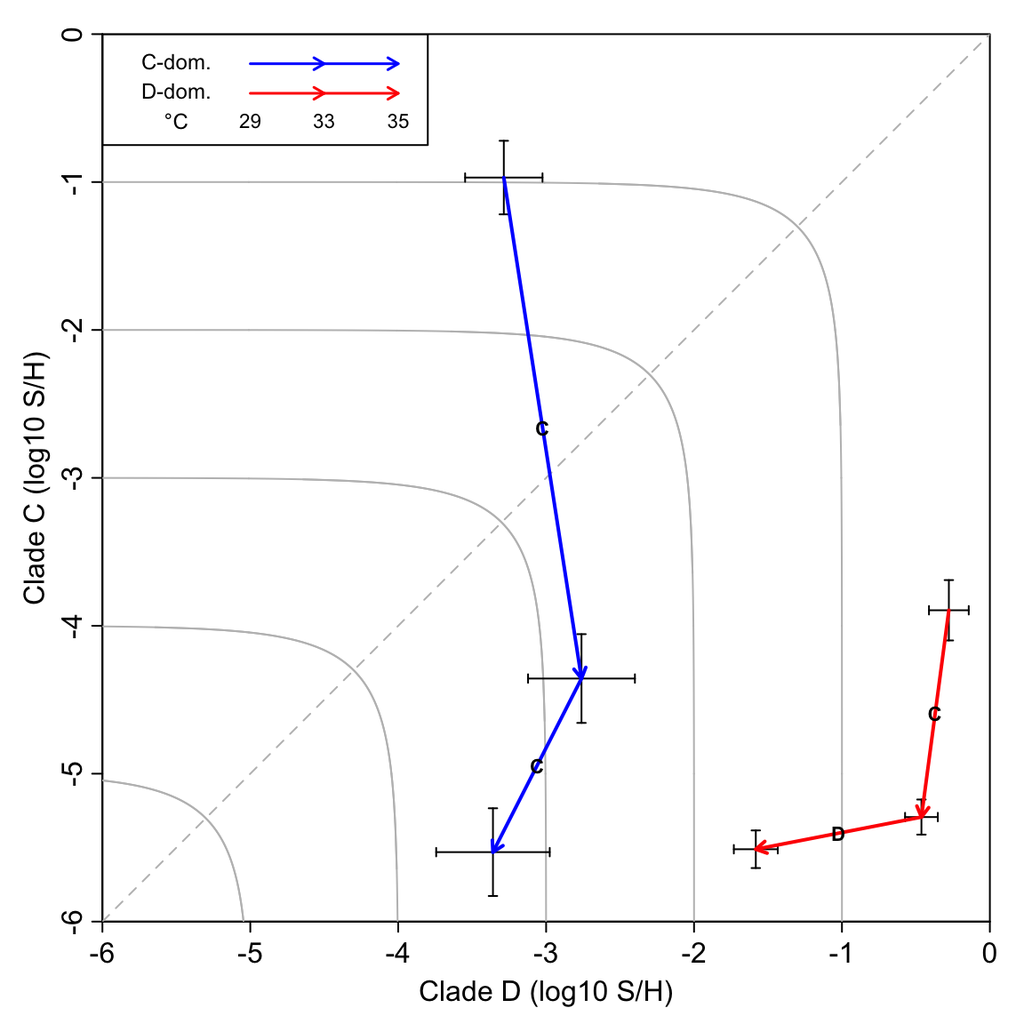

# Final figures

## Figure 1

The impact of incremental cooling (A.) and heating (B.) on relative Fv/Fm (upper panels) and total symbiont abundance (lower panels). For Fv/Fm, mean ± SD at each time point are plotted along with the fitted GAMM (solid lines) and 84% confidence intervals (shaded region) for initially C-dominated corals (blue) and D-dominated corals (red). Non-overlapping 84% confidence intervals indicate a significant difference between C and D corals at p < 0.05. For symbiont abundance, the mean of log-transformed total S/H ratios ± SD at each time point are plotted for intially C-dominated (blue) and D-dominated (red) corals. Significant differences within each group relative to initial values are indicated by an asterisk, along with the percent reduction in total S/H ratio. The horizontal axis displays days since the experiment began (below axis), and the temperature (°C) corals experienced during each weeklong increment (above axis).

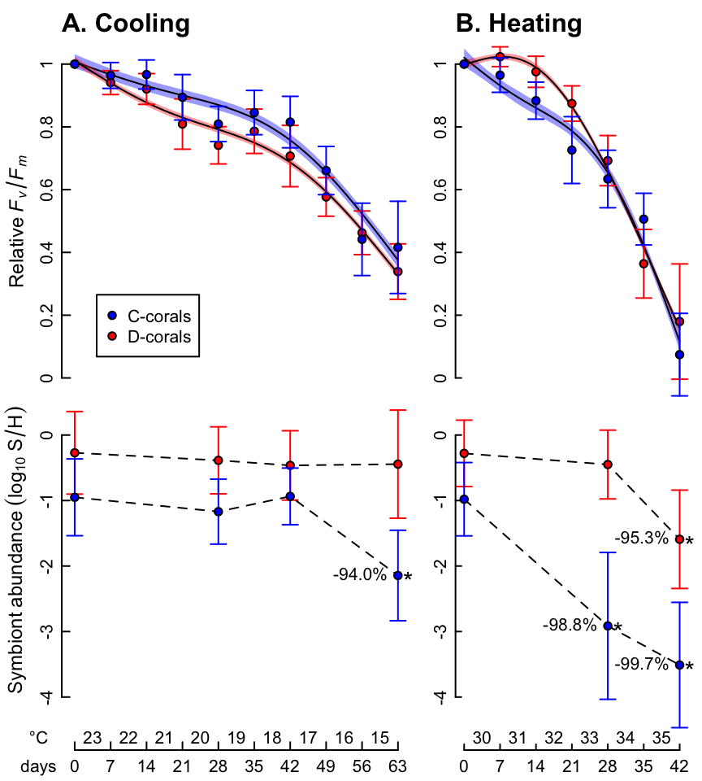

## Figure 2

Dynamics of both dominant and subdominant symbionts in corals during incremental cooling (A.) and heating (B.) Fitted values of mean abundance of clade C and D symbionts in both C-dominated (blue) and D-dominated (red) corals from linear mixed models are plotted ± SE. Arrows connect consecutive time points corresponding to temperatures indicated in the legend. Letters at the midpoint of an arrow represent a statistically significant change in the abundance of the clade indicated at the specific time interval (p < 0.05). The dashed diagonal line represents equal abundances of clades C and D, and gray contours represent equal sum total abundance of C and D (i.e., constant total S/H) at order of magnitude intervals.

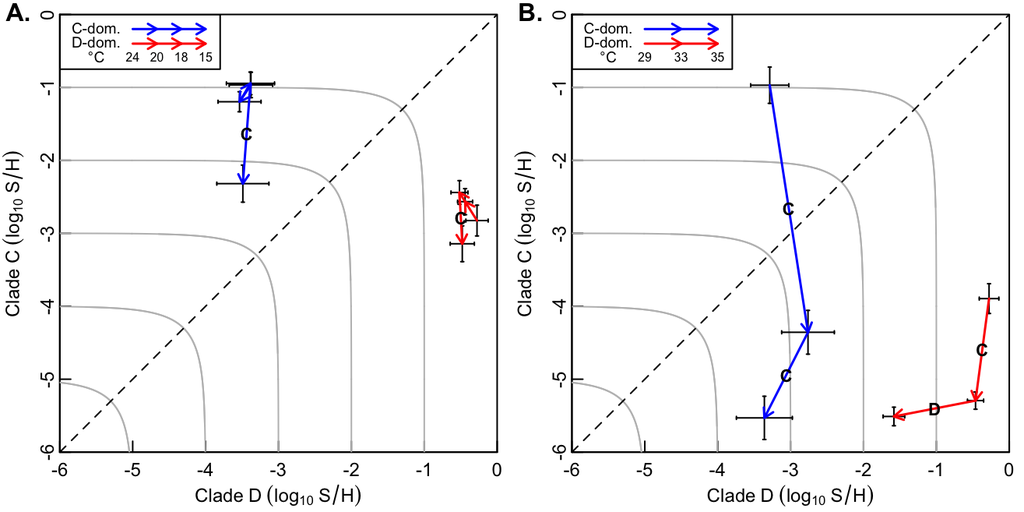